# Complete Journey Customer Transactions

[Anupreet Gupta](https://www.linkedin.com/in/guptaanupreet/) , [Palash Arora](https://www.linkedin.com/in/palash-arora/)

## Who are my customers?

### Business Understanding

#### Introduction:

[figure not shown]

#### Problem Statement:

- What constitutes majority of Kroger’s customer base? How is it changing over time?
- Who are the benefactors of loyalty program and which are the demographics where loyalty program is most effective?

#### Solution Overview:

- Identify proportion of customers with various demographic traits using household data
- Observe increases in loyalty program participation for various customer demographics
- Observe any shifts in these proportions between years 2016 and 2017
- Study shopping behavior of these high shift customers

#### Business Application

- Knowing the composition of customer base would help Kroger understand its untapped potential
- Understanding customers who benefit from the loyalty card program

### Required Packages / Functions Used

#### Required Packages

Prior installing and loading the following package would result in smooth execution of codes to reproduce the project.

List of Required Packages

| Package | Purpose |
| --- | --- |
| tidyverse | Creating Tidy and data and ease of installation of other package |
| data.table | Importing Huge Data sets; Function fread |
| ggplot2 | Creating Visuals |
| lubridate | Rectify Data format across tables |
| readr | Importing CSV files |
| DT | Creating functional tables in HTML |
| knitr | Useful in generating dynamic reports |
| rmarkdown | Converting R Markdown files into HTML/required format |
| magrittr | For Pipe operator |
| sqldf | To ease for writing SQL queries in R |

#### Defined Functions

Defined several functions based on the use cases, where a chunk of codes were repeated several times. Defining function helped to overcome repeatedly writing the same set of codes and avoiding mistakes at the same time.

- **1. Importing Data sets**

```r
read_fun <- function(file){
  fread(file, header = TRUE,
  strip.white =  TRUE, stringsAsFactors = FALSE,
  na.strings = c("null", "NA"))
}
```

- **2. Removing Outliers**

```r
remove_outliers <- function(x, na.rm = TRUE, ...) {
  qnt <- quantile(x, probs=c(.25, .75), na.rm = na.rm, ...)
  H <- 1.5 * IQR(x, na.rm = na.rm)
  y <- x
  y[x < (qnt[1] - H)] <- NA
  y[x > (qnt[2] + H)] <- NA
  y
}
```

### Data Preparation

#### Importing Data Set

```r
data_table <- c("5000_households.csv","5000_products.csv","5000_transactions.csv")
output_table <- c("households","products","transactions")

for(d in seq_along(data_table))
{
  data <- fread(paste0("data/",data_table[d]))
  assign(output_table[d],data)
}
```

#### Cleaning

- **Step 1.** White space removal from data set while importing dataset.
- **Step 2.** Null value treatment. Identifying blank,NA,“null” as Null values.

```r
colSums(is.na(transactions))
colSums(is.na(households))
colSums(is.na(products))

households_clean <- na.omit(households)
```

- **Step 3.** Renaming Columns names as per the data dictionary provided to avoid any confusion.

```r
colnames(households) <-c("hshd_num","loyalty_flag","age_range","martial_status",
                         "income_range","homeowner_desc","hshd_composition",
                          "hh_size","children")

colnames(products) <- c("product_num","department","commodity","brand_type",
                        "natural_organic_flag")

colnames(transactions) <-c("hshd_num","basket_num","date","product_num","spend",
                            "units","store_region","week_num","year")
```

- **Step 4.** Outlier Treatment. Recreating columns for Spends and Units in Transaction tables.

```r
transactions$spend_clean <- remove_outliers(transactions$spend)

transactions$unit_clean <- remove_outliers(transactions$unit)

households_clean <- na.omit(households)
```

#### Data Validation

- **Step 1.** Checking for summary() of measure variables in Transactional table

```r
summary(transactions)
```

- **Step 2.** Formating Date Column in Transactions table

```r
transactions$date <- dmy(as.character(transactions$date))
```

```r
transactions <- subset(transactions, (spend>=0 & spend>=0))
```

- **Step 4.** Outlier treatment after observing boxplots for measure variables

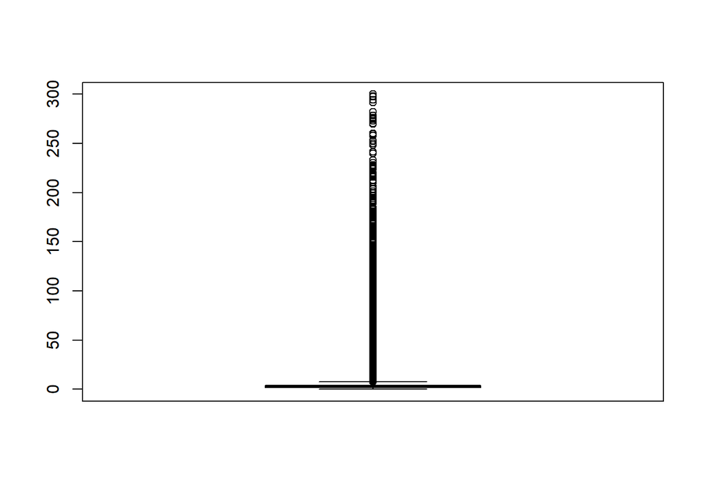

```r
boxplot(transactions$spend)
```

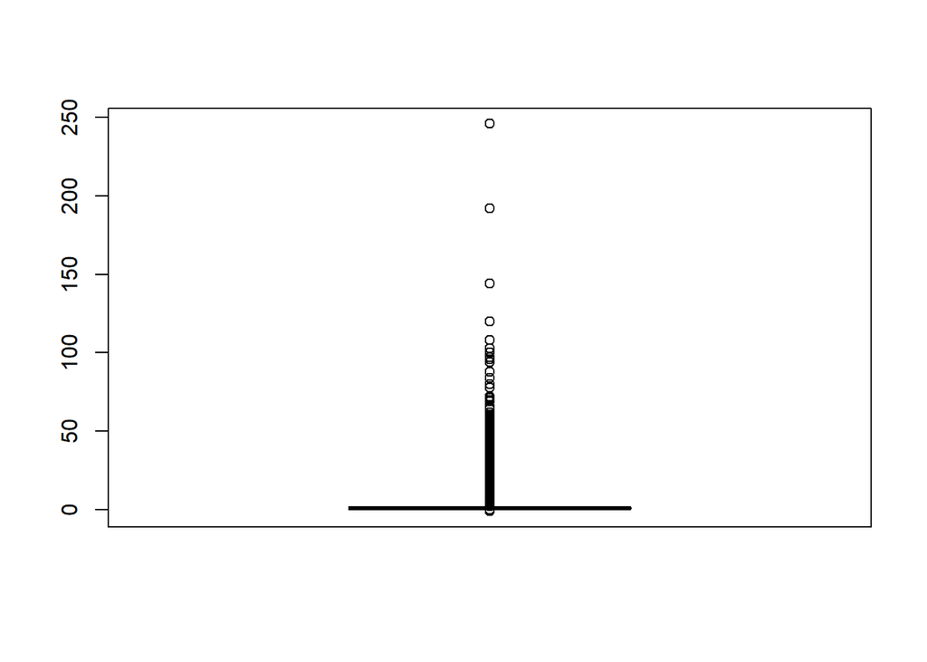

```r
boxplot(transactions$units)
```

#### Overview of Data

A look at the sample of 10 observations from each table, gives the user a chance to have a glimpse at the dataset.

- **Households**

Sample from the Households Table

| hshd_num | loyalty_flag | age_range | martial_status | income_range | homeowner_desc | hshd_composition | hh_size | children |
| --- | --- | --- | --- | --- | --- | --- | --- | --- |
| 688 | Y | 75+ | Unknown | 35-49K | Homeowner | NA | null | NOT AVAILABLE |
| 2590 | N | 75+ | Unknown | 50-74K | Homeowner | NA | null | NOT AVAILABLE |
| 1171 | Y | 75+ | Unknown | 75-99K | Homeowner | NA | null | NOT AVAILABLE |
| 1531 | Y | 75+ | Unknown | 75-99K | Homeowner | NA | null | NOT AVAILABLE |
| 403 | N | 75+ | Unknown | UNDER 35K | Renter | NA | null | NOT AVAILABLE |
| 283 | Y | 25-34 | Unknown | 50-74K | Homeowner | NA | null | NOT AVAILABLE |
| 3864 | Y | 25-34 | Unknown | 50-74K | Homeowner | NA | null | NOT AVAILABLE |
| 4899 | Y | 25-34 | Unknown | 50-74K | Homeowner | NA | null | NOT AVAILABLE |
| 1443 | N | 35-44 | Unknown | 150K+ | Homeowner | NA | null | NOT AVAILABLE |
| 3598 | Y | 35-44 | Unknown | 35-49K | Unknown | NA | null | NOT AVAILABLE |

- **Products**

Sample from the Products Table

| product_num | department | commodity | brand_type | natural_organic_flag |
| --- | --- | --- | --- | --- |
| 92993 | NON-FOOD | PET | PRIVATE | N |
| 93924 | NON-FOOD | PET | PRIVATE | N |
| 94272 | NON-FOOD | PET | PRIVATE | N |
| 94299 | NON-FOOD | PET | PRIVATE | N |
| 94594 | NON-FOOD | PET | PRIVATE | N |
| 94606 | NON-FOOD | PET | PRIVATE | N |
| 94613 | NON-FOOD | PET | PRIVATE | N |
| 95625 | NON-FOOD | PET | PRIVATE | N |
| 96152 | NON-FOOD | PET | PRIVATE | N |
| 96153 | NON-FOOD | PET | PRIVATE | N |

- **Transactions**

Sample from the Transactions Table

| hshd_num | basket_num | date | product_num | spend | units | store_region | week_num | year | spend_clean | unit_clean |
| --- | --- | --- | --- | --- | --- | --- | --- | --- | --- | --- |
| 34 | 1253 | 2016-01-03 | 539501 | 2.19 | 1 | EAST | 1 | 2016 | 2.19 | 1 |
| 60 | 1595 | 2016-01-03 | 5260099 | 0.99 | 1 | WEST | 1 | 2016 | 0.99 | 1 |
| 60 | 1595 | 2016-01-03 | 4535660 | 2.50 | 2 | WEST | 1 | 2016 | 2.50 | NA |
| 168 | 3393 | 2016-01-03 | 5602916 | 4.50 | 1 | SOUTH | 1 | 2016 | 4.50 | 1 |
| 199 | 4558 | 2016-01-03 | 5683532 | 3.49 | 1 | SOUTH | 1 | 2016 | 3.49 | 1 |
| 252 | 3491 | 2016-01-03 | 980450 | 2.79 | 1 | SOUTH | 1 | 2016 | 2.79 | 1 |
| 355 | 4733 | 2016-01-03 | 735993 | 1.00 | 1 | EAST | 1 | 2016 | 1.00 | 1 |
| 366 | 4369 | 2016-01-03 | 138157 | 9.98 | 2 | EAST | 1 | 2016 | NA | NA |
| 379 | 226 | 2016-01-03 | 83880 | 1.29 | 1 | EAST | 1 | 2016 | 1.29 | 1 |
| 413 | 2668 | 2016-01-03 | 89361 | 1.79 | 1 | WEST | 1 | 2016 | 1.79 | 1 |

### Exploratory Data Analysis

#### Data Dictionary

Variable Description of **Households** Table

[output not shown]

Variable Description of **Products** Table

| Variable | Description |
| --- | --- |
| product_num | Uniquely identifies each product |
| department | Groups products at Food, Non-Food, Pharma |
| commodity | Groups products together at lower level than Department |
| brand_type | Identifies the product as Private or National |
| natural_organic_flag | Identifies the product as Natural/Organic or Inorganic |

Variable Description of **Transactions** Table

[output not shown]

#### Analysis

##### **Merging Transactions, Products and Households into one single table**

```r
data_joined <- sqldf("Select t.*,p.*,h.*
                     from transactions t
                     Left Join products p on p.product_num=t.product_num
                     Left Join households_clean h on h.hshd_num=t.hshd_num
                     ")
data_joined$month <- month(data_joined$date)
```

Sample from the Merged Table

| hshd_num | basket_num | date | product_num | spend | units | store_region | week_num | year | spend_clean | unit_clean | product_num..12 | department | commodity | brand_type | natural_organic_flag | hshd_num..17 | loyalty_flag | age_range | martial_status | income_range | homeowner_desc | hshd_composition | hh_size | children | month |
| --- | --- | --- | --- | --- | --- | --- | --- | --- | --- | --- | --- | --- | --- | --- | --- | --- | --- | --- | --- | --- | --- | --- | --- | --- | --- |
| 34 | 1253 | 2016-01-03 | 539501 | 2.19 | 1 | EAST | 1 | 2016 | 2.19 | 1 | 539501 | FOOD | CANNED GOODS | NATIONAL | N | 34 | Y | 55-64 | Married | 50-74K | Homeowner | 2 Adults and Kids | 3 | 1 | 1 |
| 60 | 1595 | 2016-01-03 | 5260099 | 0.99 | 1 | WEST | 1 | 2016 | 0.99 | 1 | 5260099 | FOOD | PRODUCE | NATIONAL | N | 60 | Y | 45-54 | Married | 150K+ | Homeowner | 2 Adults and Kids | 5+ | 3+ | 1 |
| 60 | 1595 | 2016-01-03 | 4535660 | 2.50 | 2 | WEST | 1 | 2016 | 2.50 | NA | 4535660 | FOOD | PRODUCE | NATIONAL | N | 60 | Y | 45-54 | Married | 150K+ | Homeowner | 2 Adults and Kids | 5+ | 3+ | 1 |
| 168 | 3393 | 2016-01-03 | 5602916 | 4.50 | 1 | SOUTH | 1 | 2016 | 4.50 | 1 | 5602916 | FOOD | DELI | PRIVATE | N | 168 | Y | 55-64 | Married | 50-74K | Homeowner | 2 Adults | 2 | NOT AVAILABLE | 1 |
| 199 | 4558 | 2016-01-03 | 5683532 | 3.49 | 1 | SOUTH | 1 | 2016 | 3.49 | 1 | 5683532 | FOOD | DELI | NATIONAL | N | 199 | Y | 45-54 | Married | 50-74K | Homeowner | 2 Adults and Kids | 3 | 1 | 1 |
| 252 | 3491 | 2016-01-03 | 980450 | 2.79 | 1 | SOUTH | 1 | 2016 | 2.79 | 1 | 980450 | FOOD | BAKERY | NATIONAL | N | 252 | Y | 45-54 | Single | 75-99K | Unknown | 1 Adult and Kids | 2 | 1 | 1 |
| 355 | 4733 | 2016-01-03 | 735993 | 1.00 | 1 | EAST | 1 | 2016 | 1.00 | 1 | 735993 | FOOD | GROCERY STAPLE | NATIONAL | N | 355 | Y | null | null | null | null | null | null | null | 1 |
| 366 | 4369 | 2016-01-03 | 138157 | 9.98 | 2 | EAST | 1 | 2016 | NA | NA | 138157 | FOOD | GROCERY STAPLE | NATIONAL | N | 366 | Y | null | null | null | null | null | null | null | 1 |
| 379 | 226 | 2016-01-03 | 83880 | 1.29 | 1 | EAST | 1 | 2016 | 1.29 | 1 | 83880 | NON-FOOD | HOUSEHOLD | PRIVATE | N | 379 | Y | 55-64 | Married | 100-150K | Homeowner | 2 Adults | 2 | NOT AVAILABLE | 1 |
| 413 | 2668 | 2016-01-03 | 89361 | 1.79 | 1 | WEST | 1 | 2016 | 1.79 | 1 | 89361 | FOOD | GROCERY STAPLE | PRIVATE | N | 413 | Y | 35-44 | Single | 35-49K | Renter | Single Male | 1 | NOT AVAILABLE | 1 |

##### **Objective**

The objective of this analysis is to use Kroger data to find patterns and behaviors indicating health of the business and potential opportunities.

##### **Sales around the year:**

In order to understand the overall picture, we begin by looking at the average sales by month.

```r
monthly_sales <-  transactions %>%
                    group_by(Month = month(date), Year = year(date)) %>%
                    summarize(spend=sum(spend)) %>%
                    group_by(Month) %>%
                    summarize(spend = mean(spend)) %>%
                    arrange(Month) %>%
                    data.frame %>%
                    mutate(Month = as.factor(Month))
```

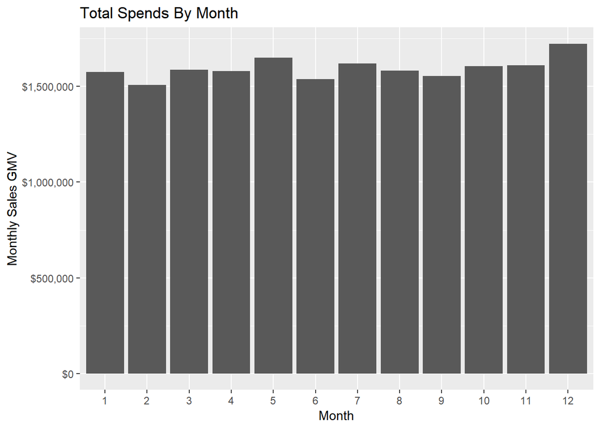

**Observation:**

- As can be seen, the sales remain about same throughout the year except in December presumably due to holiday season.
- Total sales increased by ~1% between year 2016 and 2017

Is this spike in sales caused by a larger volume of customers or a larger basket size? Let’s find out next.

##### **Average basket spends by month:**

```r
avg_basket_sales <-  transactions %>%
                      group_by(hshd_num, basket_num, Month = month(date)) %>%
                      summarize(basket_spend=sum(spend))

avg_basket_sales2 <- avg_basket_sales %>%
                      group_by(Month) %>%
                      summarize(monthly_avg_basket_spend = mean(basket_spend)) %>%
                      arrange(Month) %>%
                      data.frame %>%
                      mutate(Month = as.factor(Month))
```

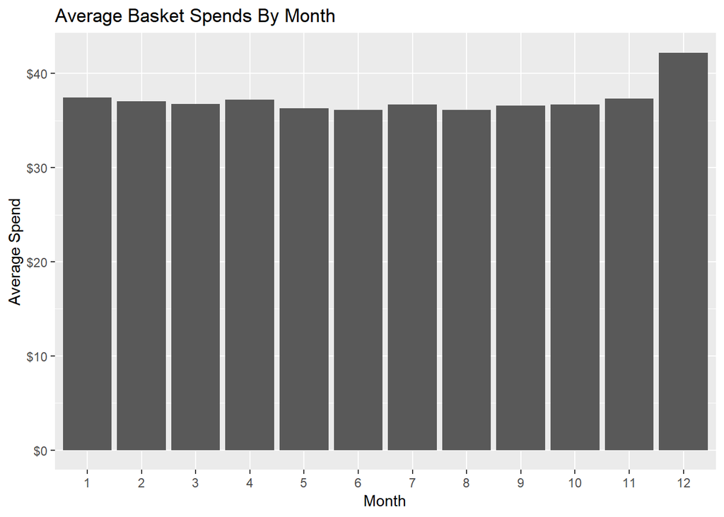

**Observation:**

- Average basket spend by month indicates that high sales is primarily driven by existing customers buying more volume of products in December.

Now, we want to understand what type of customers purchase most from Krogers. It would improve our understanding of typical Kroger customer and highlight potential customer groups Kroger can tap into

##### **Who are my customers?**

**Best Performing Demographics Profile**

**Total sales by household:**

```r
hshd_sales <- transactions %>%
                group_by(hshd_num) %>%
                summarize(sales = sum(spend))

merged_transactions <- merge(hshd_sales, households, by = "hshd_num")
```

```r
nrow(hshd_sales)
```

```
## [1] 996726
```

```r
nrow(merged_transactions)
```

```
## [1] 4982
```

```r
(1 - nrow(merged_transactions)/nrow(hshd_sales))
```

```
## [1] 0.9950016
```

**Challenges:**

**Average Spends and Households:**

```r
spend_profile <-  na.omit(merged_transactions) %>%
  group_by(loyalty_flag, martial_status, income_range, hh_size, age_range) %>%
  summarize(avg_spend = mean(sales), hh_count = n()) %>%
  filter(hh_count >= 10) %>% #removing cases where sample size is < 10 households
  arrange(desc(avg_spend))
```

Sample from the spend_profile Table

| loyalty_flag | martial_status | income_range | hh_size | age_range | avg_spend | hh_count |
| --- | --- | --- | --- | --- | --- | --- |
| N | Married | 100-150K | 2 | 55-64 | 71.42273 | 11 |
| Y | Single | 75-99K | 1 | 55-64 | 60.79696 | 23 |
| Y | Married | UNDER 35K | 2 | 45-54 | 58.38462 | 13 |
| N | Single | 35-49K | 1 | 45-54 | 56.52300 | 10 |
| Y | Married | 50-74K | 4 | 35-44 | 55.66357 | 14 |
| Y | Married | UNDER 35K | 5+ | 45-54 | 55.44583 | 12 |
| Y | Married | 50-74K | 4 | 45-54 | 53.47000 | 19 |
| Y | Single | UNDER 35K | 1 | 55-64 | 50.58133 | 15 |
| Y | Married | 50-74K | 3 | 55-64 | 49.29250 | 44 |
| N | Single | 50-74K | 1 | 45-54 | 49.04900 | 10 |
| Y | Single | 75-99K | 1 | 25-34 | 47.92765 | 17 |
| Y | Married | 100-150K | 4 | 55-64 | 47.54600 | 10 |
| Y | Married | UNDER 35K | 3 | 75+ | 46.95750 | 20 |
| Y | Married | 150K+ | 5+ | 45-54 | 46.77933 | 30 |
| Y | Single | 50-74K | 1 | 45-54 | 45.31155 | 58 |
| Y | Married | 100-150K | 2 | 65-74 | 44.63308 | 13 |
| Y | Single | 50-74K | 1 | 65-74 | 44.17900 | 10 |
| Y | Married | UNDER 35K | 2 | 55-64 | 43.92407 | 27 |
| Y | Single | 100-150K | 1 | 45-54 | 43.80886 | 35 |
| Y | Single | 75-99K | 1 | 35-44 | 43.50957 | 23 |

**Observation:**

Next, we also want to look at the fastest-growing customer demographics of customers to identify potential future customers.

##### **Fastest growing demographics profile**

**YoY change in Average Spends by Customer Demographics**

```r
hshd_sales_16 <- transactions %>%
                  filter(year == 2016) %>%
                  group_by(hshd_num) %>%
                  summarize(sales_16 = sum(spend),hh_16 = n())

hshd_sales_17 <- transactions %>%
                  filter(year == 2017) %>%
                  group_by(hshd_num) %>%
                  summarize(sales_17 = sum(spend),hh_17 = n())

merged_transactions_16_17 <- merge(hshd_sales_16, hshd_sales_17, by = "hshd_num")
```

```r
yearly_demographics <- merge(merged_transactions_16_17, households, by = "hshd_num")
```

**Observation:**

- We looked at the shopping trends of customers who shopped repeatedly in both years 2016 and 2017 but could not do so due to limitation in demographics data.

**Challenges:**

- On merging the data for customers who have repeatedly shopped with the customer demographics table; it has returned zero information indicating that households table have no information regarding these customers.
- This could be a major setback for the company, as not having information or demographics related data about regular customers can led loss of sales or not understanding their needs.

Retaining existing customers is equally important as acquiring new ones for any large scale business like Kroger. Which is why we want to understand customer retention rates.

```r
length(unique(merged_transactions_16_17$hshd_num))
```

```
## [1] 3520
```

```r
length(unique(hshd_sales_16$hshd_num))
```

```
## [1] 516720
```

**Takeaway:**

##### **Retention of Customers**

- Year Over Year: Out of 2016 shoppers how many shopped again in 2017
- Month over Month:

**Retain rate:** How many customer shop in consecutive months?

**Reactivation rate:** How many customers shop again after having shopped from Kroger in past?

```r
hshd_month <- transactions %>%
  filter(year == 2016) %>%
  mutate( Month = month(date)) %>%
  select(hshd_num, Month) %>%
  unique %>%
  mutate(next_month = Month + 1)
```

Sample from the Customer M-o-M Table

| hshd_num | Month | next_month |
| --- | --- | --- |
| 34 | 1 | 2 |
| 60 | 1 | 2 |
| 168 | 1 | 2 |
| 199 | 1 | 2 |
| 252 | 1 | 2 |
| 355 | 1 | 2 |
| 366 | 1 | 2 |
| 379 | 1 | 2 |
| 413 | 1 | 2 |
| 462 | 1 | 2 |

```r
hshd_month %>%
  group_by(hshd_num) %>%
  summarise(cnt = n()) %>% arrange(desc(cnt))
```

[output not shown]

**Observation:**

- Due to limitations with transaction data, we do not find significant number of households visiting Kroger more than once.

**Challenges:**

Identifying M-o-M, New, Retained and Reactivated customers for Kroger could help them understand their customer in-depth. It could also help in assessing on what sort of customers, they need to focus on during their marketing campaign. Retention rate of customers also is very important metric, which due to randomness or missing information cannot be evaluated here.

After analyzing sales and demographics traits, we want to sales by product types.

##### **Sales by Region**

```r
region_wise_sale <- data_joined %>%
  group_by(year,month,store_region) %>%
  summarise(gmv = sum(spend_clean,na.rm=T),
  sales = sum(unit_clean,na.rm=T)) %>%
  arrange(year,month,store_region)
```

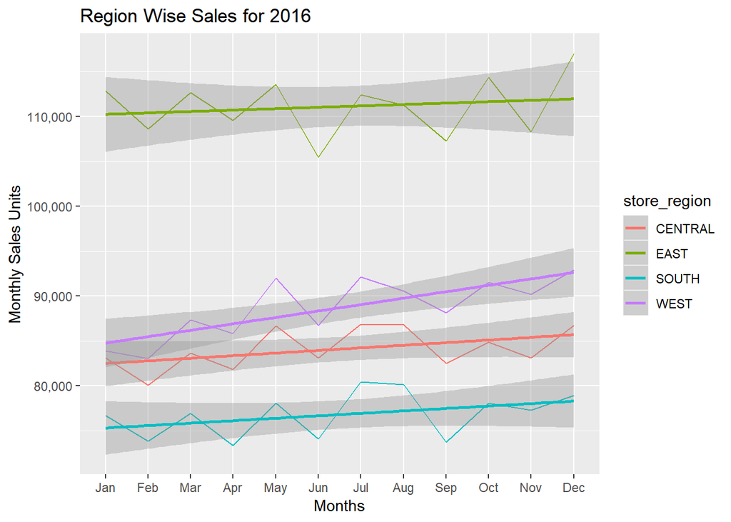

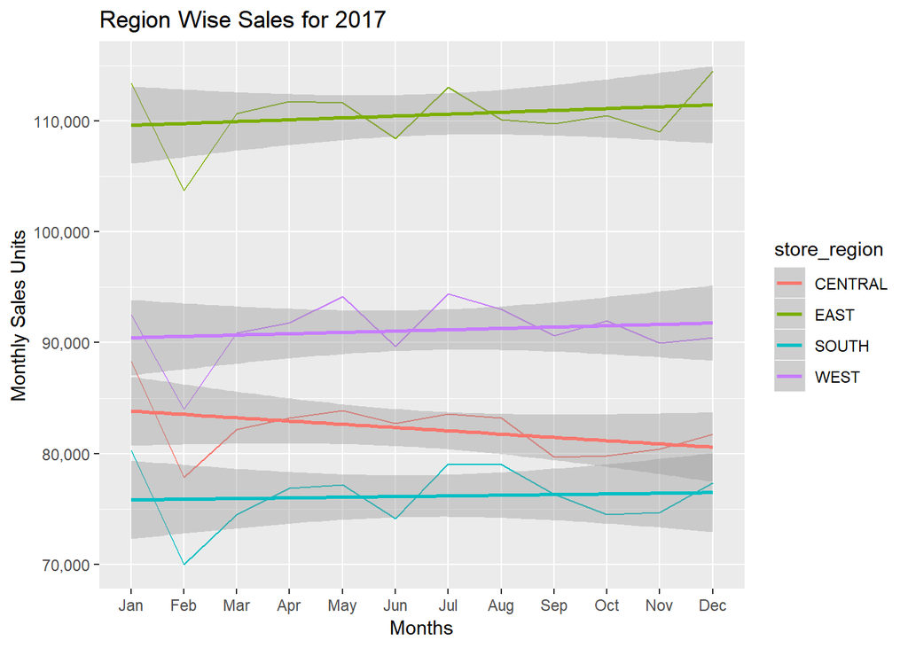

**Observations:**

- East region stores have been the best performing in terms of sales volume in comparison to the other stores.
- While there was Month-Over-Month growth in sales volume during 2016 for West and Central regions, sales have been stagnant for West and declining for Central in 2017.

Next, we want to observe sales by product type. One important product categorization is Private Vs National brands. Selling private brands promotes brand loyalty towards Kroger while also providing higher profit margins than national brands.

##### **Sales by Brand Type**

Private labels are items manufactured and market under the Kroger brand, which have higher margin in comparison to National label.

```r
brand_type_wise_sale <- data_joined %>%
  group_by(year,month,brand_type) %>%
  summarise(gmv = sum(spend_clean,na.rm=T),
  sales = sum(unit_clean,na.rm=T)) %>%
  arrange(year,month,brand_type)
```

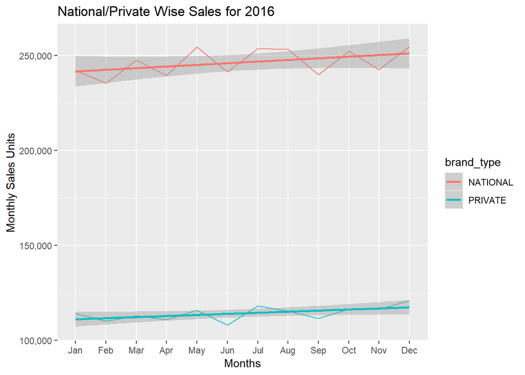

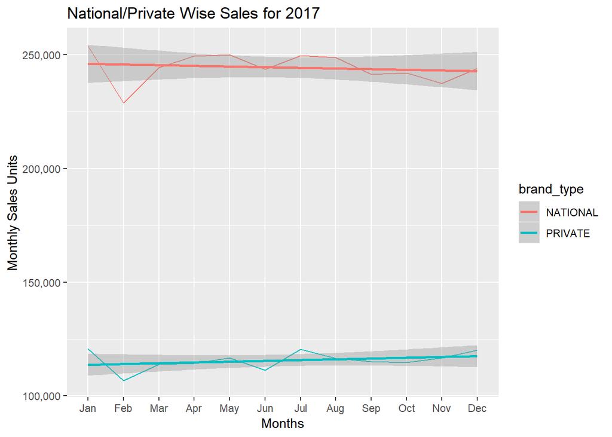

**Observations:**

- The private brands for Kroger contributes ~ 32 % of their total sales, which have seen a growth of 0.5 % over 2016 to 2017.

### Summary

The objective of this analysis is to use Kroger data to find patterns and behaviors indicating health of the business and potential opportunities. Below is a summary of key findings.

**Overall performance by year:**

- Total sales of Kroger increased by ~1% between year 2016 and 2017.

**Best performing months:**

- Sales are highest in December presumably due to holiday season.
- The high sales is driven primarily by existing customers buying a high volume of products.

**Private brands sales performance:**

Selling private brands promotes brand loyalty towards Kroger while also providing higher profit margins than National brands. We found:

- The private brands for Kroger contribute ~ 32 % of their total sales, which have seen a growth of 0.5 % over 2016 to 2017.

**Best performing regions:**

- East region stores have been the best performing in terms of sales volume.
- While there was Month-Over-Month growth in sales volume during 2016 for West and Central regions, sales has been stagnant for West and declining for Central in 2017.

### Next Steps & Recommendations

- Looking at the data, there seems to be huge gap in how the data is collated for every household. The company to boosts sales and enchance customer experience and loyalty should be putting into use the customer data already available with them but the process of collecting customer information needs to be streamlined.
- Understanding on a monthly level, Retained vs Reactivated vs New customers coming to the stores. Further, understanding of these three groups could help marketing campaigns in an effective manner.
- Given, the iformation on customer, KNN Clustering could be performed to identify groups of customers with similar shopping patterns and hence sales and inventories could be planned well ahead of an event.
- A predictive model could be built to assit in understanding the monthly sales for any region. This information could be help in evaluating the prospectives of opening a new store in the region given the demographics of that region is known in advance.